# Species, diabetes data set

# Overview

This document addresses three research questions:

1. **Global diabetes effect** — Is there any difference in the gut microbiome of diabetics vs. non-diabetics across the whole dataset?
2. **China-specific diabetes effect** — Is there any difference in the gut microbiome of diabetics vs. non-diabetics within China?
3. **East vs. West in diabetics** — Is there any geographical difference in the gut microbiome of diabetics across Western and Eastern lifestyles?

# Setup

## Libraries

```r
library(phyloseq)
library(vegan)
library(dplyr)
library(tibble)
library(purrr)
library(stringr)
library(ggplot2)
library(ape)
library(tidyverse)
library(ggh4x)
library(lme4)
library(lmerTest)
library(broom.mixed)
```

## Load Data

```r
path <- "../data/D003924_phyloseq_updated_species.RData"
ps <- get(load(path))

meta <- as(sample_data(ps), "matrix") %>% as.data.frame()
otu  <- as(otu_table(ps),   "matrix") %>% as.data.frame()
tax  <- as(tax_table(ps),   "matrix") %>% as.data.frame()
tree <- phy_tree(ps)
```

## Sequencing depth

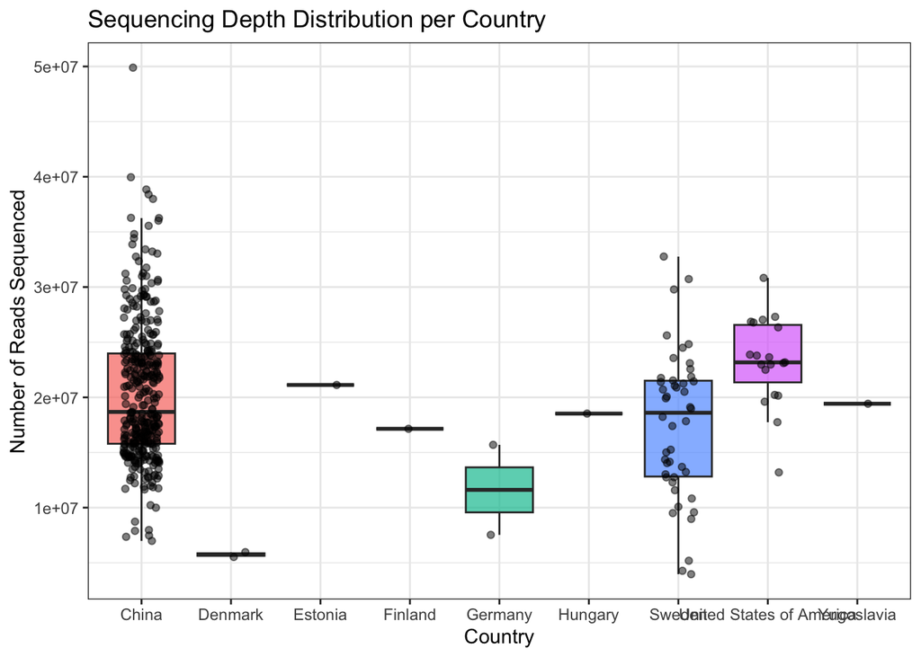

```r
# Extract metadata safely into a standard data frame
depth_df <- as(sample_data(ps), "matrix") %>% as.data.frame()

# Ensure the column is treated as a numeric value for plotting
depth_df$Nr..reads.sequenced <- as.numeric(depth_df$Nr..reads.sequenced)

# Plot boxplot of sequencing depth per country
ggplot(depth_df, aes(x = Country, y = Nr..reads.sequenced, fill = Country)) +
  geom_boxplot(outlier.shape = NA, alpha = 0.7) +
  geom_jitter(width = 0.2, alpha = 0.5, size = 1.5) +
  labs(
    x = "Country",
    y = "Number of Reads Sequenced",
    title = "Sequencing Depth Distribution per Country"
  ) +
  theme_bw() +
  theme(legend.position = "none")
```

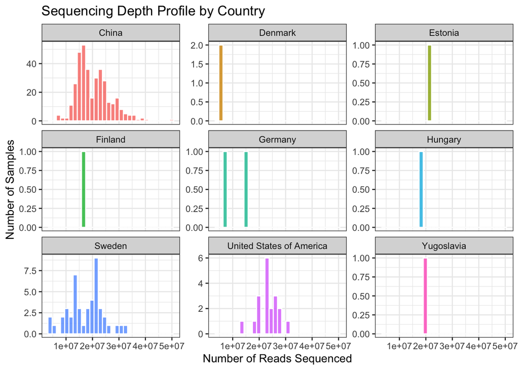

```r
# Extract metadata safely into a standard data frame
depth_df <- as(sample_data(ps), "matrix") %>% as.data.frame()
depth_df$Nr..reads.sequenced <- as.numeric(depth_df$Nr..reads.sequenced)

# Plot histograms faceted by country
ggplot(depth_df, aes(x = Nr..reads.sequenced, fill = Country)) +
  geom_histogram(bins = 30, color = "white", alpha = 0.8) +
  facet_wrap(~ Country, scales = "free_y") +
  labs(
    x = "Number of Reads Sequenced",
    y = "Number of Samples",
    title = "Sequencing Depth Profile by Country"
  ) +
  theme_bw() +
  theme(legend.position = "none")
```

```r
# Example using your Analysis 3 subset framework (Europe vs China)
kruskal.test(Nr..reads.sequenced ~ Country, data = depth_df)
```

```
##
##  Kruskal-Wallis rank sum test
##
## data:  Nr..reads.sequenced by Country
## Kruskal-Wallis chi-squared = 23.631, df = 8, p-value = 0.002642
```

## Data Overview

```r
table(meta$Sex,                    useNA = "always")
```

```
##
##        Female   Male   <NA>
##     19    203    210      0
```

```r
table(meta$Country,                useNA = "always")
```

```
##
##                    China                  Denmark                  Estonia
##                      359                        2                        1
##                  Finland                  Germany                  Hungary
##                        1                        2                        1
##                   Sweden United States of America               Yugoslavia
##                       46                       19                        1
##                     <NA>
##                        0
```

```r
table(meta$Disease.MESH.ID,        useNA = "always")
```

```
##
## D003924 D006262    <NA>
##     260     172       0
```

```r
table(meta$Recent.antibiotics.use, useNA = "always")
```

```
##
##         N    Y <NA>
##   54  374    4    0
```

```r
table(meta$Country, meta$Disease.MESH.ID, useNA = "always")
```

```
##
##                            D003924 D006262 <NA>
##   China                        187     172    0
##   Denmark                        2       0    0
##   Estonia                        1       0    0
##   Finland                        1       0    0
##   Germany                        2       0    0
##   Hungary                        1       0    0
##   Sweden                        46       0    0
##   United States of America      19       0    0
##   Yugoslavia                     1       0    0
##   <NA>                           0       0    0
```

```r
cat("Max library size:", max(sample_sums(ps)), "\n")
```

```
## Max library size: 0.9931466
```

```r
cat("NAs – Host.age:", sum(is.na(meta$Host.age)), "\n")
```

```
## NAs – Host.age: 0
```

```r
cat("NAs – BMI:",      sum(is.na(meta$BMI)),      "\n")
```

```
## NAs – BMI: 262
```

```r
# Confirm data are relative abundances (all values ≤ 1)
cat("Values > 1 (should be 0 for rel. abundance):", sum(otu_table(ps) > 1), "\n")
```

```
## Values > 1 (should be 0 for rel. abundance): 0
```

```r
# All columns
mean(colSums(otu_table(ps)))
```

```
## [1] 0.7070114
```

## Prepare Phyloseq Objects and Subsets

```r
# ── Recode western countries ──────────────────────────────────────────────────
europe <- c("Denmark", "Estonia", "Finland", "Germany",
             "Hungary", "Sweden", "Yugoslavia")

sample_data(ps)$Country <- as.character(sample_data(ps)$Country)
sample_data(ps)$Country[sample_data(ps)$Country %in% europe] <- "Europe"
sample_data(ps)$Country <- factor(sample_data(ps)$Country)

# ── Analysis subsets ──────────────────────────────────────────────────────────
# Analysis 1: whole dataset (diabetics D003924 vs healthy D006262)
ps_global <- ps

# Analysis 2: China only (diabetics vs healthy)
ps_china  <- subset_samples(ps, Country == "China")

# Analysis 3: diabetics only (West vs China)
ps_we     <- subset_samples(ps, Disease.MESH.ID == "D003924" & Sex == "Female" &  Country %in% c("Europe", "China"))
```

```r
remove_zero_taxa <- function(ps) {
  filter_taxa(ps, function(x) sum(x) > 0, prune = TRUE)
}

ps_global <- remove_zero_taxa(ps_global)
ps_china  <- remove_zero_taxa(ps_china)
ps_we     <- remove_zero_taxa(ps_we)

cat("Taxa remaining after zero-removal:\n")
```

```
## Taxa remaining after zero-removal:
```

```r
cat("  ps_global:", ntaxa(ps_global), "\n")
```

```
##   ps_global: 173
```

```r
cat("  ps_china: ", ntaxa(ps_china),  "\n")
```

```
##   ps_china:  155
```

```r
cat("  ps_we:    ", ntaxa(ps_we),     "\n")
```

```
##   ps_we:     118
```

```r
mean(colSums(otu_table(ps_china)))
```

```
## [1] 0.7195386
```

```r
ps_sick <- subset_samples(ps_china, Disease.MESH.ID %in% c("D003924"))
ps_healthy <- subset_samples(ps_china, Disease.MESH.ID %in% c("D006262"))
mean(colSums(otu_table(ps_sick)))
```

```
## [1] 0.6986862
```

```r
mean(colSums(otu_table(ps_healthy)))
```

```
## [1] 0.7422096
```

```r
mean(colSums(otu_table(ps_we)))
```

```
## [1] 0.6556072
```

```r
ps_we_europe <- subset_samples(ps_we, Country %in% c("Europe"))
ps_we_china <- subset_samples(ps_we, Country %in% c("China"))
mean(colSums(otu_table(ps_we_europe)))
```

```
## [1] 0.6177704
```

```r
mean(colSums(otu_table(ps_we_china)))
```

```
## [1] 0.6856541
```

## Transformed Phyloseq Objects

```r
make_transforms <- function(ps) {
  list(
    rel = transform_sample_counts(ps, function(x) x / sum(x)),
    pa  = transform_sample_counts(ps, function(x) ifelse(x > 0, 1, 0)),
    clr = transform_sample_counts(ps, function(x) { x <- x + 1e-9; log(x) - mean(log(x)) })
  )
}

global_t <- make_transforms(ps_global)
china_t  <- make_transforms(ps_china)
we_t     <- make_transforms(ps_we)
```

### Data

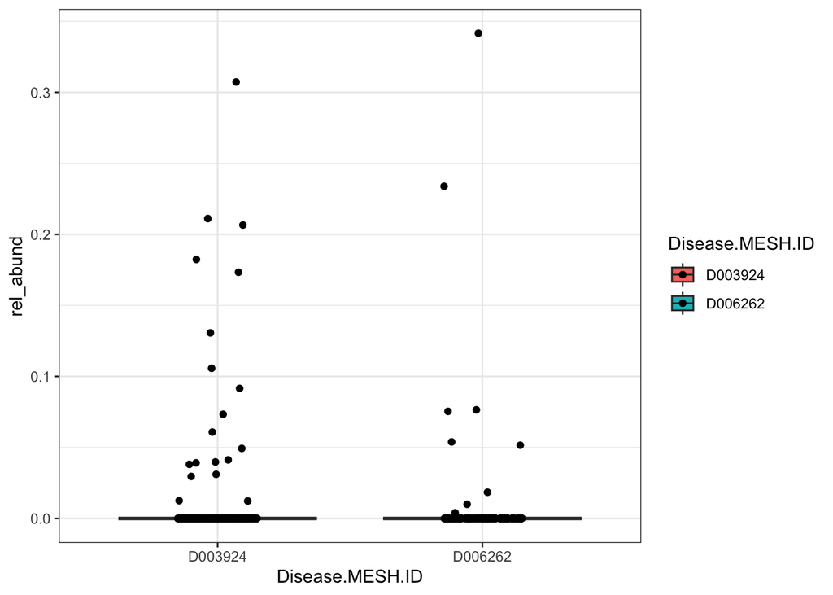

```r
ps_rel <- transform_sample_counts(ps, function(x) x / sum(x))
otu_rel <- as(otu_table(ps_rel), "matrix") %>% t() %>% as.data.frame()
meta_rel <- as(sample_data(ps_rel), "matrix") %>% as.data.frame()
tax_rel <- as(tax_table(ps_rel), "matrix") %>% as.data.frame()
ps_species <- tax_glom(ps_rel, taxrank = "Species")

dat_rel <- otu_rel %>%
  rownames_to_column("sample_id") %>%
  pivot_longer(-sample_id, names_to = "taxon", values_to = "rel_abund") %>%
  left_join(meta_rel %>% as("data.frame") %>% rownames_to_column("sample_id"), by = "sample_id") %>%
  left_join(tax_rel %>% rownames_to_column("taxon"), by = "taxon")

one_taxon <- dat_rel$taxon[3]


# Comparison between body sites
dat_rel %>%
  filter(taxon == one_taxon) %>%
  ggplot(aes(x = Disease.MESH.ID, y = rel_abund, fill = Disease.MESH.ID)) +
    geom_boxplot(outlier.shape = NA) +
    geom_jitter(width = 0.15) +
    theme_bw()
```

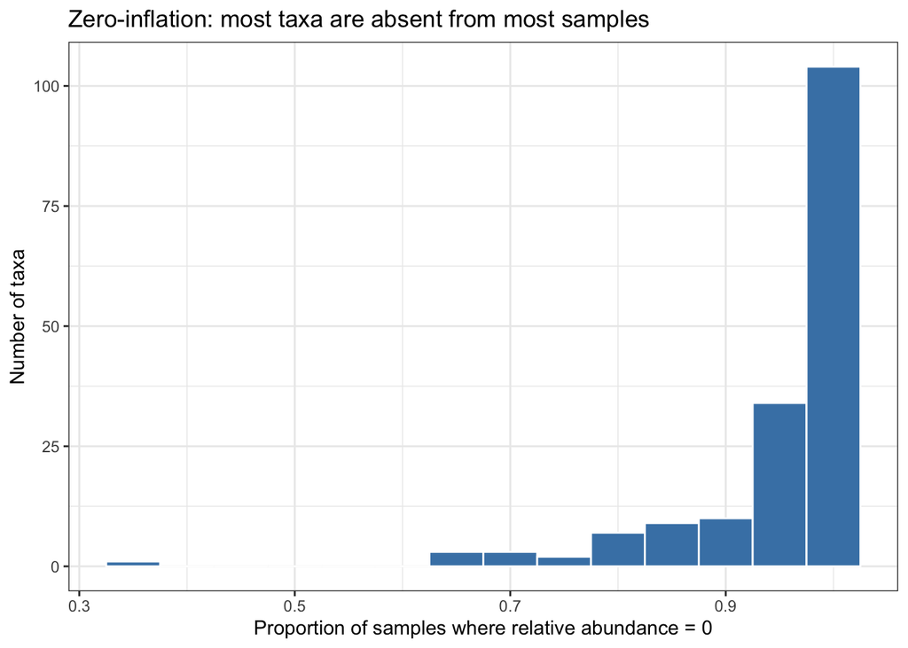

```r
dat_rel %>%
  filter(Disease.MESH.ID == "D003924") %>%
  group_by(taxon) %>%
  summarise(prop_zero = mean(rel_abund == 0), .groups = "drop") %>%
  ggplot(aes(x = prop_zero)) +
    geom_histogram(binwidth = 0.05, fill = "steelblue", color = "white") +
    labs(x = "Proportion of samples where relative abundance = 0",
         y = "Number of taxa",
         title = "Zero-inflation: most taxa are absent from most samples") +
    theme_bw()
```

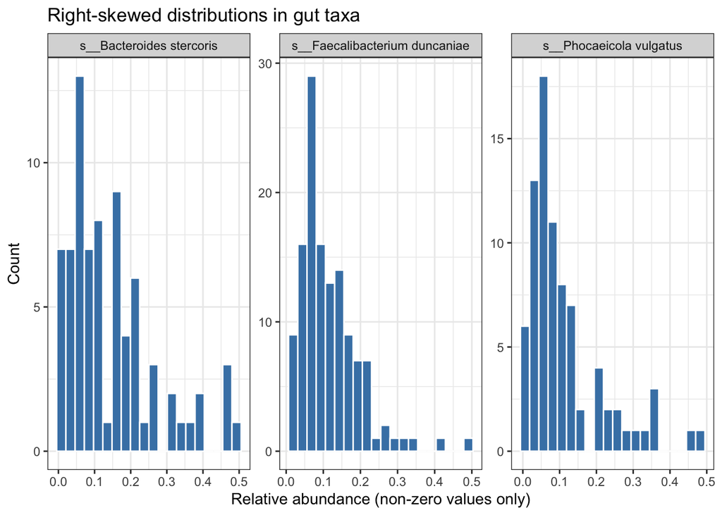

```r
set.seed(42)
example_taxa <- dat_rel %>%
  filter(Disease.MESH.ID == "D006262") %>%
  group_by(taxon, Genus, Species) %>%
  summarise(prop_nonzero = mean(rel_abund > 0), .groups = "drop") %>%
  filter(prop_nonzero > 0.4, prop_nonzero < 0.9) %>%
  slice_sample(n = 6) %>%
  pull(taxon)

dat_rel %>%
  filter(Disease.MESH.ID == "D006262", taxon %in% example_taxa, rel_abund > 0) %>%
  mutate(label = ifelse(!is.na(Species) & Species != "", Species, Genus)) %>%
  ggplot(aes(x = rel_abund)) +
    geom_histogram(bins = 20, fill = "steelblue", color = "white") +
    facet_wrap(~ label, scales = "free") +
    labs(x = "Relative abundance (non-zero values only)",
         y = "Count",
         title = "Right-skewed distributions in gut taxa") +
    theme_bw()
```

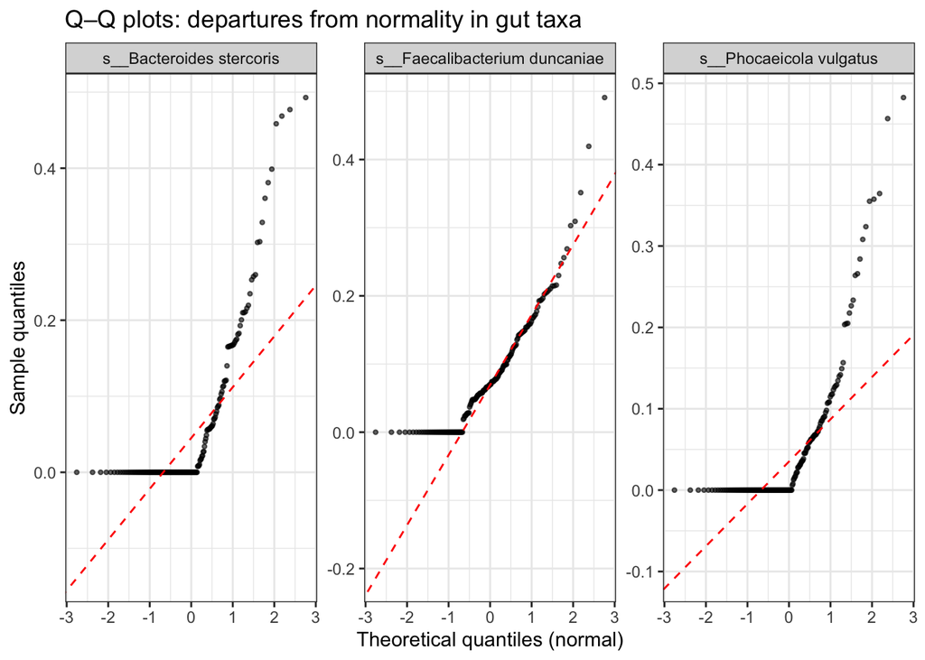

```r
dat_rel %>%
  filter(Disease.MESH.ID == "D006262", taxon %in% example_taxa) %>%
  mutate(label = ifelse(!is.na(Species) & Species != "", Species, Genus)) %>%
  ggplot(aes(sample = rel_abund)) +
    stat_qq(size = 0.8, alpha = 0.6) +
    stat_qq_line(color = "red", linetype = "dashed") +
    facet_wrap(~ label, scales = "free") +
    labs(x = "Theoretical quantiles (normal)",
         y = "Sample quantiles",
         title = "Q–Q plots: departures from normality in gut taxa") +
    theme_bw()
```

## Helper Functions

```r
# Random subsample of samples from a phyloseq object
sample_ps <- function(ps, FUN = sample, ...) {
  prune_samples(FUN(sample_names(ps), ...), ps)
}

# Alpha-diversity data frame (Shannon + Observed) joined to metadata
make_alpha_df <- function(ps, ps_pa) {
  shannon  <- estimate_richness(ps,    measures = "Shannon")  %>% rownames_to_column("sample_id")
  observed <- estimate_richness(ps_pa, measures = "Observed") %>% rownames_to_column("sample_id")
  meta_df  <- sample_data(ps) %>% data.frame() %>% rownames_to_column("sample_id")

  inner_join(shannon, observed, by = "sample_id") %>%
    inner_join(meta_df, by = "sample_id")
}

# Kruskal-Wallis over multiple grouping variables
run_kruskal <- function(data, response_var, group_vars) {
  map_dfr(group_vars, function(gv) {
    res <- kruskal.test(as.formula(paste(response_var, "~", gv)), data = data)
    data.frame(Variable = gv, Chi_squared = res$statistic,
               df = res$parameter, P_value = res$p.value)
  })
}

# Pairwise Wilcoxon over multiple grouping variables
run_pairwise_wilcoxon <- function(data, response_var, group_vars) {
  map_dfr(group_vars, function(gv) {
    res <- pairwise.wilcox.test(data[[response_var]], data[[gv]],
                                p.adjust.method = "bonferroni")
    as.data.frame(res$p.value) %>%
      rownames_to_column("Group1") %>%
      pivot_longer(-Group1, names_to = "Group2", values_to = "P_value_adj") %>%
      drop_na(P_value_adj) %>%
      mutate(Variable = gv, Comparison = paste(Group1, "vs", Group2)) %>%
      select(Variable, Comparison, P_value_adj, Group1, Group2)
  })
}

# CLR linear model across all taxa, returning results for one term
run_clr_lm <- function(ps_clr, formula_str, term_filter) {
  otu_clr  <- as(otu_table(ps_clr),  "matrix") %>% t() %>% as.data.frame()
  meta_clr <- as(sample_data(ps_clr), "matrix") %>% as.data.frame()
  tax_clr  <- as(tax_table(ps_clr),  "matrix") %>% as.data.frame()

  otu_clr %>%
    rownames_to_column("sample_id") %>%
    pivot_longer(-sample_id, names_to = "taxon", values_to = "clr") %>%
    left_join(meta_clr %>% rownames_to_column("sample_id"), by = "sample_id") %>%
    left_join(tax_clr  %>% rownames_to_column("taxon"),     by = "taxon") %>%
    mutate(
      sex    = factor(Sex,            levels = c("Female", "Male")),
      status = factor(Disease.MESH.ID, levels = c("D006262", "D003924")),
      country= factor(Country,         levels = c("China", "Europe", "United States of America")),
      age    = as.numeric(Host.age),
      bmi    = as.numeric(BMI),
      depth  = as.numeric(Nr..reads.sequenced)
    ) %>%
    group_by(taxon, Phylum, Genus, Species) %>%
    group_modify(~ broom::tidy(lm(as.formula(formula_str), data = .x))) %>%
    filter(term == term_filter) %>%
    ungroup() %>%
    mutate(q_value = p.adjust(p.value, method = "BH"))
}

# Volcano plot from CLR results
plot_volcano <- function(clr_res, x_label, title,
                         pos_label = "Enriched (+)", neg_label = "Enriched (-)") {
  clr_res %>%
    mutate(
      neg_log10_q = -log10(q_value),
      direction   = case_when(
        q_value < 0.05 & estimate > 0 ~ pos_label,
        q_value < 0.05 & estimate < 0 ~ neg_label,
        TRUE ~ "Not significant"
      )
    ) %>%
    ggplot(aes(x = estimate, y = neg_log10_q, color = direction,
               label = ifelse(!is.na(Species) & Species != "", Species, Genus))) +
      geom_point(alpha = 0.6, size = 2) +
      scale_color_manual(values = c(setNames("#E74C3C", pos_label),
                                    setNames("#3498DB", neg_label),
                                    "Not significant" = "grey60")) +
      geom_hline(yintercept = -log10(0.05), linetype = "dashed", color = "grey40") +
      geom_vline(xintercept = 0,            linetype = "dashed", color = "grey40") +
      labs(x = x_label, y = "-log10(q-value)", color = NULL, title = title) +
      theme_bw()
}

# Top-taxa bar chart from CLR results
plot_top_taxa <- function(clr_res, n = 10, x_label, title,
                          pos_label = "Enriched (+)", neg_label = "Enriched (-)",
                          pos_color = "#E74C3C", neg_color = "#3498DB") {
  bind_rows(
    clr_res %>% filter(q_value < 0.05) %>% arrange(estimate)  %>% head(n),
    clr_res %>% filter(q_value < 0.05) %>% arrange(-estimate) %>% head(n)
  ) %>%
    distinct() %>%
    mutate(
      direction    = ifelse(estimate > 0, pos_label, neg_label),
      display_name = ifelse(!is.na(Species) & Species != "", Species, Genus)
    ) %>%
    ggplot(aes(x = reorder(display_name, estimate), y = estimate, fill = direction)) +
      geom_col() +
      coord_flip() +
      scale_fill_manual(values = c(setNames(pos_color, pos_label),
                                   setNames(neg_color, neg_label))) +
      labs(x = NULL, y = x_label, fill = NULL, title = title) +
      theme_bw()
}

# RDA on CLR matrix: fit model, run permutation ANOVA, return rda object + clean matrices
run_rda <- function(ps_clr, formula_str, covariates) {
  otu_clr  <- as(otu_table(ps_clr),   "matrix") %>% t()
  meta_clr <- as(sample_data(ps_clr), "matrix") %>% as.data.frame() %>%
  mutate(
        across(c(Host.age, BMI, Nr..reads.sequenced), as.numeric),
        across(c(Host.age, BMI, Nr..reads.sequenced), ~ scale(.x)[, 1]),
        Sex             = factor(Sex,             levels = c("Female", "Male")),
        Disease.MESH.ID = factor(Disease.MESH.ID, levels = c("D006262", "D003924")),
        Country         = factor(Country,         levels = c("China", "Europe", "United States of America"))
      )
  na_idx       <- apply(meta_clr[, covariates, drop = FALSE], 1, anyNA)
  clr_clean    <- otu_clr[!na_idx, ]
  meta_clean   <- meta_clr[!na_idx, ]
  cat("Samples removed due to NAs:", sum(na_idx), "\n")
  cat("Samples retained:", nrow(clr_clean), "\n")
  rda_fit <- rda(as.formula(paste("clr_clean ~", formula_str)), data = meta_clean)
  list(rda = rda_fit, clr_mat = clr_clean, meta = meta_clean)
}

# RDA biplot coloured by one variable, shaped by another (both optional)
plot_rda_biplot <- function(rda_obj, meta_df,
                            color_var, shape_var = NULL,
                            color_values, shape_values = NULL,
                            title = "RDA biplot") {
  eig  <- rda_obj$CCA$eig
  pct1 <- round(eig[1] / rda_obj$tot.chi * 100, 1)
  pct2 <- round(eig[2] / rda_obj$tot.chi * 100, 1)
```

```r
  # 1. Extract site scores
  site_scores <- scores(rda_obj, display = "sites") %>%
    as.data.frame() %>%
    rownames_to_column("sample_id") %>%
    left_join(meta_df %>% rownames_to_column("sample_id"), by = "sample_id")

  # 2. Dynamically determine the orientation sign of RDA1 inside the function
  unique_groups <- unique(site_scores[[color_var]])
  group1 <- unique_groups[1]
  rda1_scores_all <- scores(rda_obj, display = "sites")[, "RDA1"]
  rda1_sign <- ifelse(mean(rda1_scores_all[meta_df[[color_var]] == group1], na.rm = TRUE) >= 0, 1, -1)

  # Apply direction alignment to sites
  site_scores <- site_scores %>% mutate(RDA1 = RDA1 * rda1_sign)

  # 3. Extract environmental biplot arrow scores and apply sign alignment
  bp_scores <- scores(rda_obj, display = "bp") %>%
    as.data.frame() %>%
    mutate(RDA1 = RDA1 * rda1_sign) %>%
    rownames_to_column("variable")

  # 4. Safely extract species/genus mappings from the global 'tax' matrix
  # fallback to extracting species scores using vegan's correct 'species' display argument
  top_species_scores <- scores(rda_obj, display = "species") %>%
    as.data.frame() %>%
    mutate(RDA1 = RDA1 * rda1_sign) %>%
    rownames_to_column("taxon") %>%
    # Use the global 'tax' matrix directly to look up Genus names safely
    left_join(tax %>% rownames_to_column("taxon"), by = "taxon") %>%
    head(10) %>%
    mutate(label = ifelse(!is.na(Species) & Species != "", Species, Genus))

  # Scale coordinates for visualization consistency
  site_range  <- max(abs(c(site_scores$RDA1, site_scores$RDA2)))
  arrow_scale <- site_range * 0.8 / max(sqrt(bp_scores$RDA1^2 + bp_scores$RDA2^2))
  species_scale <- site_range * 0.6 / max(sqrt(top_species_scores$RDA1^2 + top_species_scores$RDA2^2))

  top_species_scores <- top_species_scores %>% mutate(RDA1 = RDA1 * species_scale, RDA2 = RDA2 * species_scale)
  bp_scores   <- bp_scores %>% mutate(RDA1 = RDA1 * arrow_scale, RDA2 = RDA2 * arrow_scale)

  aes_map <- if (!is.null(shape_var)) {
    aes(x = RDA1, y = RDA2,
        color = .data[[color_var]], shape = .data[[shape_var]])
  } else {
    aes(x = RDA1, y = RDA2, color = .data[[color_var]])
  }

  p <- ggplot() +
    geom_point(data = site_scores, mapping = aes_map, size = 3, alpha = 0.85) +
    # Taxa vectors
    geom_segment(data = top_species_scores,
                 aes(x = 0, y = 0, xend = RDA1, yend = RDA2),
                 arrow = arrow(length = unit(0.15, "cm")),
                 color = "grey70", linewidth = 0.5) +
    geom_text(data = top_species_scores,
              aes(x = RDA1 * 1.15, y = RDA2 * 1.15, label = label),
              size = 2.5, color = "grey50", fontface = "italic") +
    # Biplot constraint arrows
    geom_segment(data = bp_scores,
                 aes(x = 0, y = 0, xend = RDA1, yend = RDA2),
                 arrow = arrow(length = unit(0.25, "cm")),
                 color = "black", linewidth = 1) +
    geom_text(data = bp_scores,
              aes(x = RDA1 * 1.15, y = RDA2 * 1.15, label = variable),
              size = 3.5, fontface = "bold") +
    scale_color_manual(values = color_values) +
    labs(x = paste0("RDA1 (", pct1, "% of total variance)"),
         y = paste0("RDA2 (", pct2, "% of total variance)"),
         title = title) +
  theme_bw() +
  theme(aspect.ratio = 1) +
  coord_fixed()

  if (!is.null(shape_var) && !is.null(shape_values)) {
    p <- p + scale_shape_manual(values = shape_values)
  }
  p


}
# Join RDA taxon loadings with CLR univariate estimates and flag agreement
compare_rda_clr <- function(rda_obj, clr_res, tax_df, rda1_sign = 1) {
  # Change display = "genus" to display = "species"
  taxon_scores <- scores(rda_obj, display = "species")[, 1] * rda1_sign

  tibble(taxon = names(taxon_scores), rda1_loading = taxon_scores) %>%
    left_join(tax_df %>% rownames_to_column("taxon"), by = "taxon") %>%
    left_join(
      clr_res %>% select(taxon, Phylum, Genus,
                         clr_estimate = estimate, clr_q = q_value),
      by = "taxon"
    ) %>%
    mutate(
      direction_agreement = sign(rda1_loading) == sign(clr_estimate),
      clr_result = case_when(
        clr_q < 0.05 & direction_agreement  ~ "CLR significant, same direction",
        clr_q < 0.05 & !direction_agreement ~ "CLR significant, opposite direction",
        TRUE                                ~ "CLR not significant"
      )
    ) %>%
    arrange(desc(abs(rda1_loading)))
}

# Wilcoxon rank-sum test per taxon on relative abundances.
# group_var: the column to split on (e.g. "Disease.MESH.ID" or "Country")
# pos_level: the level treated as the numerator in log2FC (e.g. "D003924" or "Europe")
# neg_level: the denominator level (e.g. "D006262" or "China")
run_wilcoxon <- function(ps_rel, group_var, pos_level, neg_level) {
  otu_rel  <- as(otu_table(ps_rel),   "matrix") %>% t() %>% as.data.frame()
  meta_rel <- as(sample_data(ps_rel), "matrix") %>% as.data.frame()
  tax_rel  <- as(tax_table(ps_rel),   "matrix") %>% as.data.frame()

  otu_rel %>%
    rownames_to_column("sample_id") %>%
    pivot_longer(-sample_id, names_to = "taxon", values_to = "rel_abund") %>%
    left_join(meta_rel %>% rownames_to_column("sample_id"), by = "sample_id") %>%
    left_join(tax_rel  %>% rownames_to_column("taxon"),     by = "taxon") %>%
    group_by(taxon, Genus, Species) %>%
    summarise(
      p_value  = wilcox.test(rel_abund ~ .data[[group_var]], exact = FALSE)$p.value,
      mean_pos = mean(rel_abund[.data[[group_var]] == pos_level], na.rm = TRUE),
      mean_neg = mean(rel_abund[.data[[group_var]] == neg_level], na.rm = TRUE),
      log2_fc  = log2((mean_pos + 1e-6) / (mean_neg + 1e-6)),
      .groups  = "drop"
    ) %>%
    mutate(q_value = p.adjust(p_value, method = "BH"))
}

# Scatter plot: Wilcoxon log2FC vs CLR estimate, coloured by significance category
# Follows the cross-method comparison in differential_abundance.Rmd
join_three_methods <- function(wilcox_res, glm_res, clr_res) {
  wilcox_res %>%
    select(taxon, Genus, Species,
           wilcox_log2fc = log2_fc, wilcox_q = q_value) %>%
    left_join(
      glm_res %>% select(taxon, glm_estimate = estimate, glm_q = q_value),
      by = "taxon"
    ) %>%
    left_join(
      clr_res %>% select(taxon, clr_estimate = estimate, clr_q = q_value),
      by = "taxon"
    ) %>%
    mutate(
      sig_wilcox = wilcox_q < 0.05,
      sig_glm    = glm_q    < 0.05,
      sig_clr    = clr_q    < 0.05,
      sig_category = case_when(
        sig_wilcox & sig_glm & sig_clr ~ "All three",
        sig_wilcox & sig_clr           ~ "Wilcoxon + CLR",
        sig_wilcox & sig_glm           ~ "Wilcoxon + GLM",
        sig_glm    & sig_clr           ~ "GLM + CLR",
        sig_wilcox                     ~ "Wilcoxon only",
        sig_glm                        ~ "GLM only",
        sig_clr                        ~ "CLR only",
        TRUE                           ~ "Not significant"
      )
    )
}
```

```r
# Signed -log10(q) heatmap across all three methods, for taxa significant in
# at least one. Mirrors the heatmap from differential_abundance.Rmd.
plot_method_heatmap <- function(comp_df, pos_direction, neg_direction, title) {
  heatmap_data <- comp_df %>%
    filter(sig_wilcox | sig_glm | sig_clr) %>%
    mutate(display_name = ifelse(!is.na(Species) & Species != "", Species, Genus)) %>%
    select(display_name,
           wilcox_log2fc, glm_estimate, clr_estimate,
           wilcox_q, glm_q, clr_q) %>%
    rename(Genus = display_name) %>%
    pivot_longer(
      cols      = c(wilcox_q, glm_q, clr_q),
      names_to  = "method", values_to = "q_value"
    ) %>%
    mutate(
      effect = case_when(
        method == "wilcox_q" ~ wilcox_log2fc,
        method == "glm_q"    ~ glm_estimate,
        method == "clr_q"    ~ clr_estimate
      ),
      signed_neg_log10_q = sign(effect) * pmin(-log10(q_value), 10),
      method = factor(method,
                      levels = c("wilcox_q", "glm_q", "clr_q"),
                      labels = c("Wilcoxon", "GLM (rel.)", "CLR"))
    )

  taxon_order <- heatmap_data %>%
    group_by(Genus) %>%
    summarise(mean_signed = mean(signed_neg_log10_q, na.rm = TRUE), .groups = "drop") %>%
    arrange(mean_signed) %>%
    pull(Genus)

  heatmap_data %>%
    mutate(Species = factor(Genus, levels = taxon_order)) %>%
    ggplot(aes(x = method, y = Genus, fill = signed_neg_log10_q)) +
      geom_tile(color = "white", linewidth = 0.5) +
      geom_text(aes(label = ifelse(q_value < 0.05, "*", "")),
                color = "black", size = 3) +
      scale_fill_gradient2(
        low      = "#C0392B", mid = "white", high = "#3498DB",
        midpoint = 0, limits = c(-10, 10),
        name     = "Signed\n-log10(q)",
        breaks   = c(-10, -5, 0, 5, 10),
        labels   = c(paste0("-10\n(", neg_direction, ")"), "-5",
                     "0", "5",
                     paste0("10\n(", pos_direction, ")"))
      ) +
      labs(x = "Method", y = NULL, title = title,
           subtitle = paste0("Blue = ", neg_direction,
                             ", Red = ", pos_direction,
                             " | * = q < 0.05")) +
      theme_bw() +
      theme(axis.text.y = element_text(size = 7, face = "italic"))
}

# n_sig summary table across all three methods
summarise_n_sig <- function(comp_df) {
  tibble(
    method        = c("Wilcoxon", "GLM (rel. abundance)", "CLR"),
    n_significant = c(
      sum(comp_df$wilcox_q < 0.05, na.rm = TRUE),
      sum(comp_df$glm_q    < 0.05, na.rm = TRUE),
      sum(comp_df$clr_q    < 0.05, na.rm = TRUE)
    )
  )
}

# Plot wilcoxon clr comparison
plot_wilcox_clr_comparison <- function(wilcox_res, clr_res,
                                       wilcox_x_label, clr_y_label, title) {
  wilcox_res %>%
    select(taxon, wilcox_log2fc = log2_fc, wilcox_q = q_value) %>%
    left_join(
      clr_res %>% select(taxon, clr_estimate = estimate, clr_q = q_value),
      by = "taxon"
    ) %>%
    mutate(
      sig_category = case_when(
        wilcox_q < 0.05 & clr_q < 0.05 ~ "Both significant",
        wilcox_q < 0.05                 ~ "Wilcoxon only",
        clr_q    < 0.05                 ~ "CLR only",
        TRUE                            ~ "Not significant"
      )
    ) %>%
    ggplot(aes(x = wilcox_log2fc, y = clr_estimate, color = sig_category)) +
      geom_point(alpha = 0.6, size = 2) +
      scale_color_manual(values = c(
        "Both significant" = "#E74C3C",
        "Wilcoxon only"    = "#E67E22",
        "CLR only"         = "#3498DB",
        "Not significant"  = "grey70"
      )) +
      geom_hline(yintercept = 0, linetype = "dashed", color = "grey40") +
      geom_vline(xintercept = 0, linetype = "dashed", color = "grey40") +
      labs(x = wilcox_x_label, y = clr_y_label, color = NULL, title = title) +
      theme_bw()
}

# Scatter plot: RDA1 loading vs CLR estimate, coloured by agreement
plot_rda_clr_comparison <- function(comparison_df, x_label, y_label, title) {
  comparison_df %>%
    ggplot(aes(x = clr_estimate, y = rda1_loading, color = clr_result)) +
      geom_hline(yintercept = 0, linetype = "dashed", color = "grey40") +
      geom_vline(xintercept = 0, linetype = "dashed", color = "grey40") +
      geom_point(alpha = 0.65, size = 2) +
      scale_color_manual(values = c(
        "CLR significant, same direction"      = "#2E8B57",
        "CLR significant, opposite direction"  = "#E67E22",
        "CLR not significant"                  = "grey70"
      )) +
      labs(x = x_label, y = y_label, color = NULL, title = title) +
      theme_bw()
}
```

# Analysis 1: Global — Diabetics vs. Non-Diabetics (Whole Dataset)

**Question:** Is there a difference in the gut microbiome between diabetics (D003924) and non-diabetics (D006262) across all countries?

## Visualisation

### Barplot (relative abundance, n = 50 sample)

[figure not shown]

```r
ps_species_global <- tax_glom(global_t$rel, taxrank = "Species")
ps_species_sampled <- sample_ps(ps_species_global, size = 50)

plot_bar(ps_species_sampled, fill = "Species") +
  facet_nested(~ Disease.MESH.ID, scales = "free_x") +
  labs(title = "Relative abundance by disease status (global, n = 50)") +
  theme(axis.text.x = element_blank())
```

### Heat map

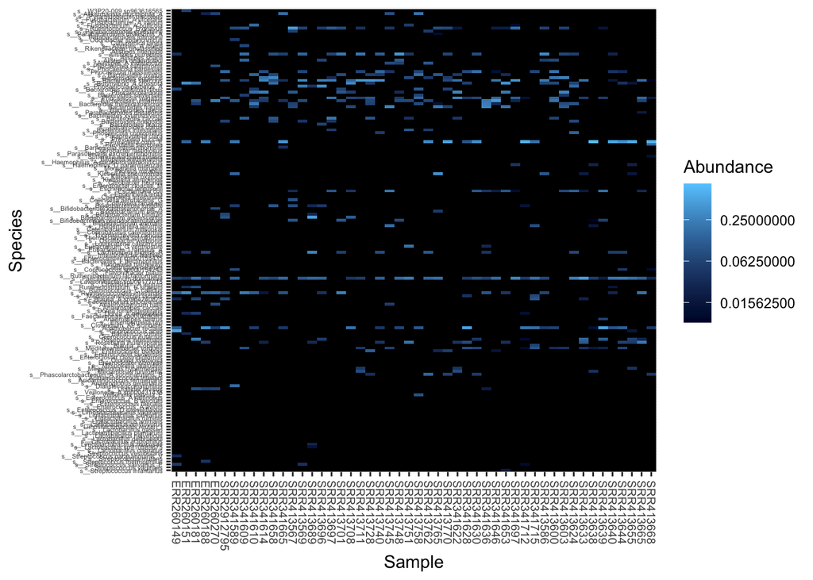

```r
plot_heatmap(ps_species_sampled, taxa.label = "Species", sample.order = 'Disease.MESH.ID')
```

## Alpha Diversity

```r
alpha_global <- make_alpha_df(ps_global, global_t$pa)
```

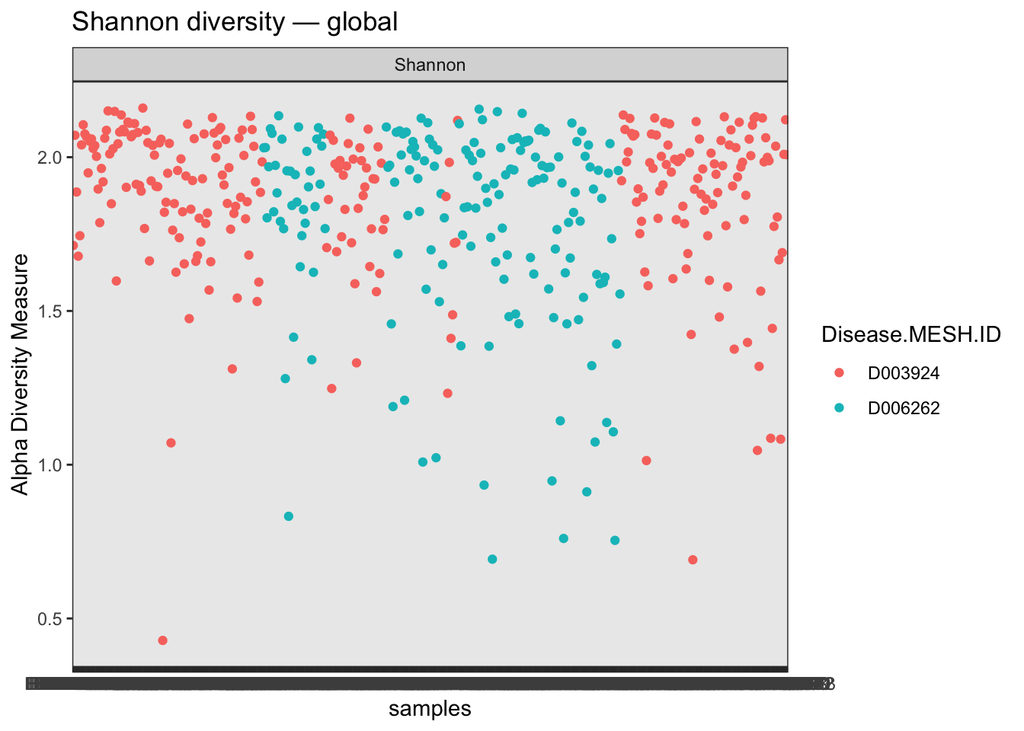

```r
plot_richness(ps_global, measures = "Shannon", color = "Disease.MESH.ID") +
  labs(title = "Shannon diversity — global") +
  theme_bw()
```

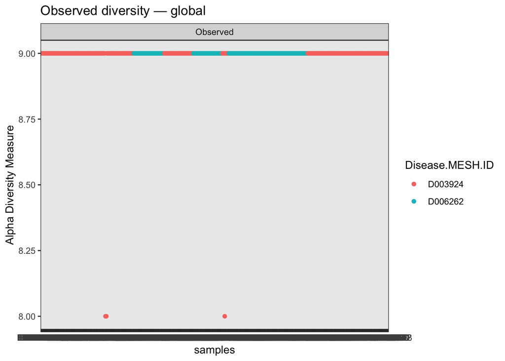

```r
plot_richness(global_t$pa, measures = "Observed", color = "Disease.MESH.ID") +
  labs(title = "Observed diversity — global") +
  theme_bw()
```

```r
run_kruskal(alpha_global, "Shannon", c("Disease.MESH.ID", "Country"))
```

```
##                                       Variable Chi_squared df      P_value
## Kruskal-Wallis chi-squared...1 Disease.MESH.ID    5.532899  1 1.866216e-02
## Kruskal-Wallis chi-squared...2         Country   21.586533  2 2.053732e-05
```

```r
run_pairwise_wilcoxon(alpha_global, "Shannon", c("Disease.MESH.ID","Country"))
```

```
## # A tibble: 4 × 5
##   Variable        Comparison                         P_value_adj Group1   Group2
##   <chr>           <chr>                                    <dbl> <chr>    <chr>
## 1 Disease.MESH.ID D006262 vs D003924                   0.0187    D006262  D0039…
## 2 Country         Europe vs China                      0.0000211 Europe   China
## 3 Country         United States of America vs China    1         United … China
## 4 Country         United States of America vs Europe   0.00395   United … Europe
```

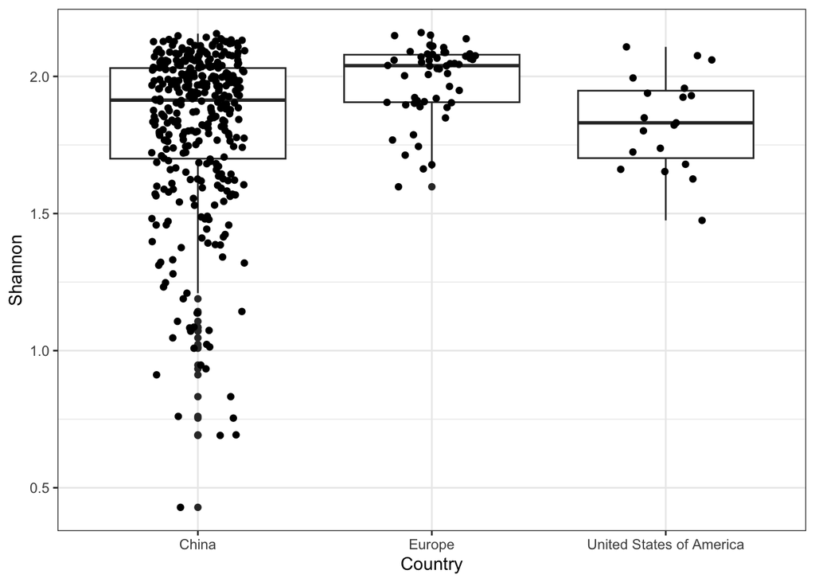

```r
ggplot(alpha_global, aes(x = Country, y = Shannon)) +
  geom_boxplot() +
  geom_jitter(width = 0.2) +
  theme_bw()
```

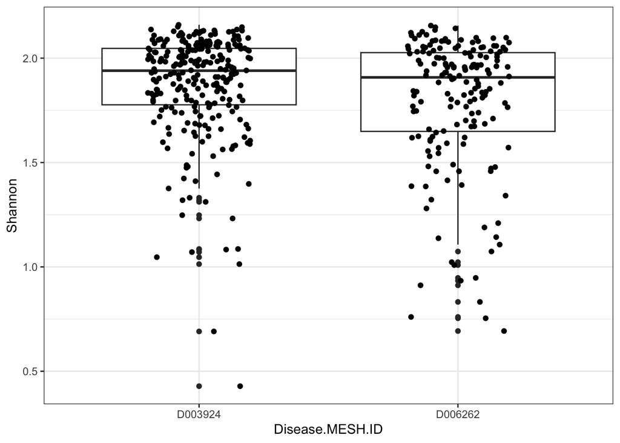

```r
ggplot(alpha_global, aes(x = Disease.MESH.ID, y = Shannon)) +
  geom_boxplot() +
  geom_jitter(width = 0.2) +
  theme_bw()
```

Negative correlation might be due to the removal of singletons.

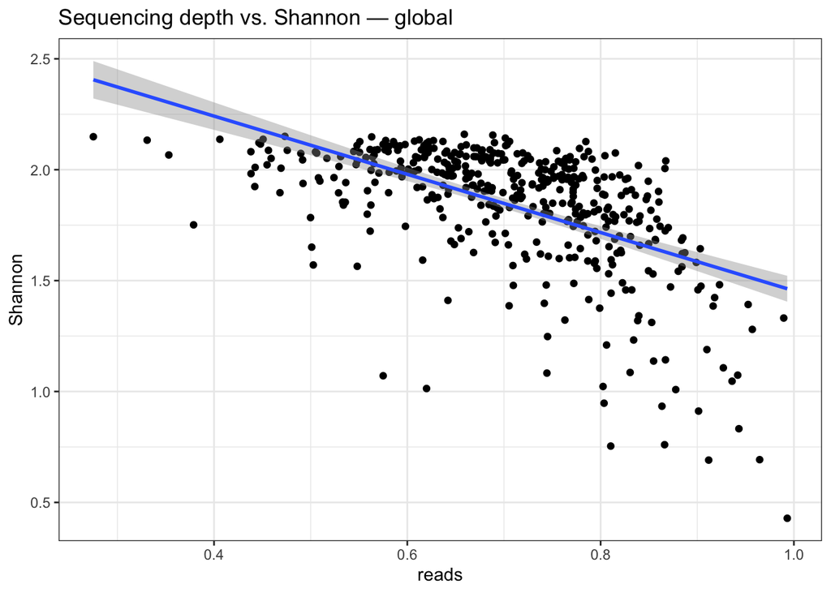

```r
alpha_global$reads <- sample_sums(ps_global)[alpha_global$sample_id]

ggplot(alpha_global, aes(x = reads, y = Shannon)) +
  geom_point() + geom_smooth(method = "lm") +
  labs(title = "Sequencing depth vs. Shannon — global") +
  theme_bw()
```

```r
cor.test(alpha_global$reads, alpha_global$Shannon, method = "spearman")
```

```
##
##  Spearman's rank correlation rho
##
## data:  alpha_global$reads and alpha_global$Shannon
## S = 21396060, p-value < 2.2e-16
## alternative hypothesis: true rho is not equal to 0
## sample estimates:
##        rho
## -0.5923412
```

## Beta Diversity

### Calculating the Bray-Curtis distances and the Jaccard distances

```r
bray_dist <- distance(
  ps_global,
  method = "bray"
)

jaccard_dist <- distance(
  global_t$pa,
  method = "jaccard"
)
```

### PCoA — Bray-Curtis

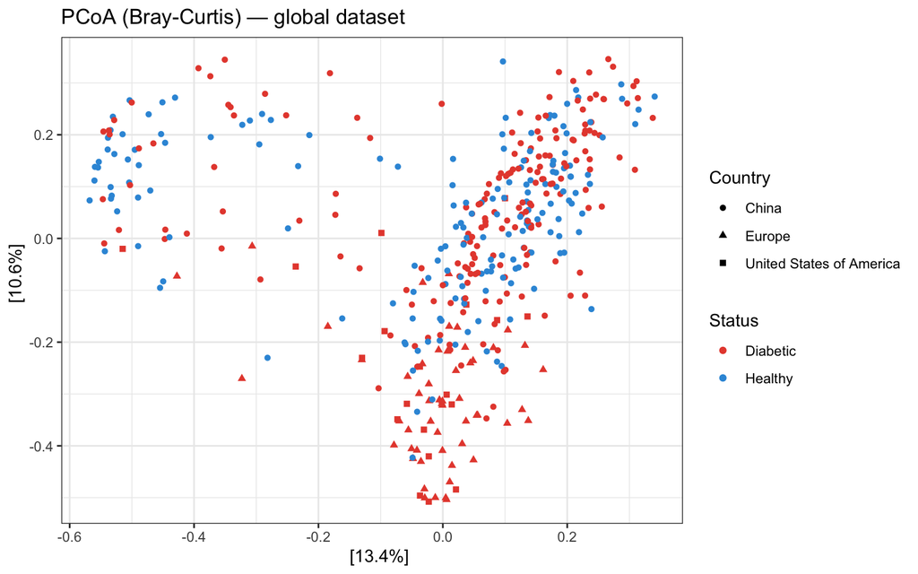

```r
bray_global <- distance(global_t$rel, method = "bray")
ord_global  <- ordinate(global_t$rel, method = "PCoA", distance = bray_global)

plot_ordination(global_t$rel, ord_global, type = "samples",
                color = "Disease.MESH.ID", shape = "Country") +
  scale_color_manual(values = c("D003924" = "#E74C3C", "D006262" = "#3498DB"),
                     labels = c("Diabetic", "Healthy")) +
  labs(title = "PCoA (Bray-Curtis) — global dataset",
       color = "Status") +
  theme_bw()
```

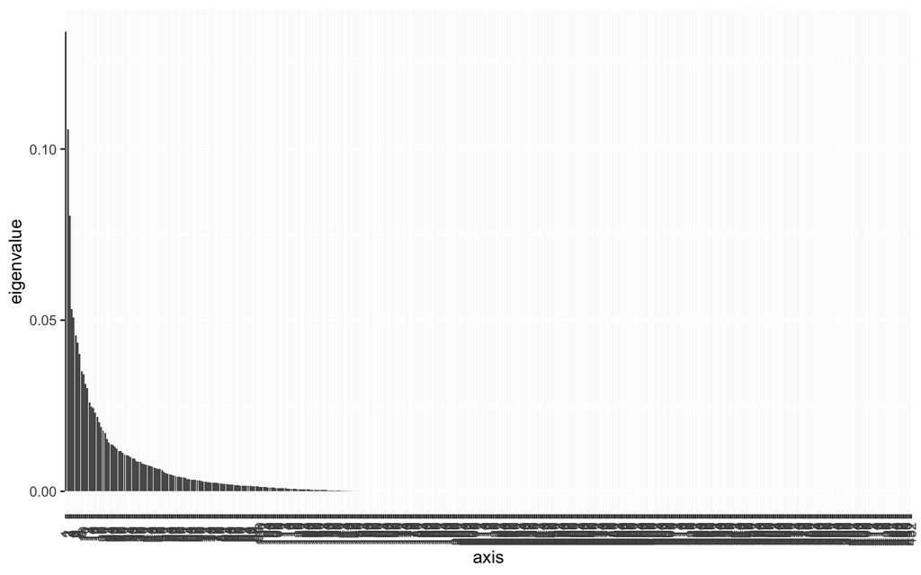

```r
plot_scree(ord_global)
```

### NMDS based on Bray-Curtis distance

NMDS is another commonly used ordination method in ecology and microbiome analysis. Unlike PCoA, it focuses on preserving the rank order of distances rather than the distances themselves.

```r
global_nmds <- ordinate(
  global_t$rel,
  method = "NMDS",
  distance = "bray"
)
```

```
## *** Best solution was not repeated -- monoMDS stopping criteria:
##      5: no. of iterations >= maxit
##     15: stress ratio > sratmax
```

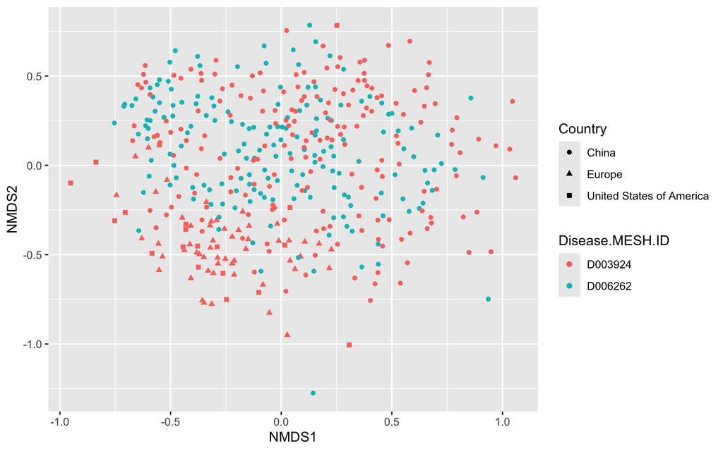

```r
plot_ordination(
  global_t$rel,
  global_nmds,
  type = "samples",
  color = "Disease.MESH.ID",
  shape = "Country"
)
```

### PERMANOVA + Dispersion

```r
sample_df_global <- sample_data(global_t$rel) %>% data.frame()

adonis2(bray_global ~ Disease.MESH.ID,
        data = sample_df_global, permutations = 999)
```

```
## Permutation test for adonis under reduced model
## Permutation: free
## Number of permutations: 999
##
## adonis2(formula = bray_global ~ Disease.MESH.ID, data = sample_df_global, permutations = 999)
##           Df SumOfSqs      R2      F Pr(>F)
## Model      1    2.286 0.01422 6.2019  0.001 ***
## Residual 430  158.469 0.98578
## Total    431  160.755 1.00000
## ---
## Signif. codes:  0 '***' 0.001 '**' 0.01 '*' 0.05 '.' 0.1 ' ' 1
```

```r
# Dispersion check
disp_global <- betadisper(bray_global, sample_df_global$Disease.MESH.ID)
anova(disp_global)
```

```
## Analysis of Variance Table
##
## Response: Distances
##            Df  Sum Sq  Mean Sq F value    Pr(>F)
## Groups      1 0.07027 0.070269  21.106 5.717e-06 ***
## Residuals 430 1.43161 0.003329
## ---
## Signif. codes:  0 '***' 0.001 '**' 0.01 '*' 0.05 '.' 0.1 ' ' 1
```

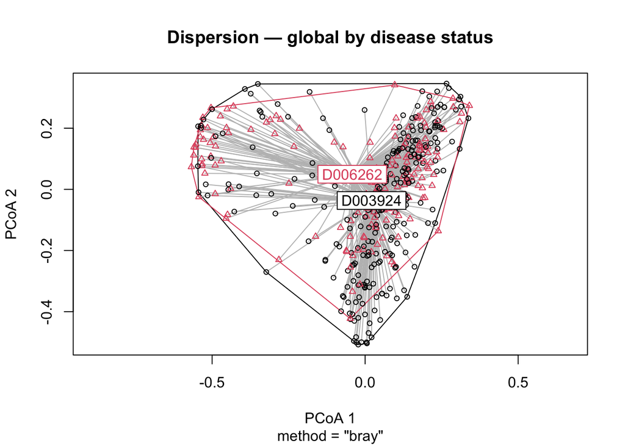

```r
plot(disp_global, main = "Dispersion — global by disease status")
```

## Compositional Analysis — CLR Linear Model

The model adjusts for sex, country, age, and sequencing depth; the term of interest is `statusD003924` (diabetic relative to healthy).

### Running CLR

```r
clr_global <- run_clr_lm(
  ps_clr       = global_t$clr,
  formula_str  = "clr ~ sex + country + status + age + depth",
  term_filter  = "statusD003924"
)


global_healthy_enriched <- clr_global %>%
  select(taxon, Genus, estimate, std.error, statistic, p.value, q_value) %>%
  arrange(estimate) %>%
  head(10)

global_sick_enriched <- clr_global %>%
  select(taxon, Genus, estimate, std.error, statistic, p.value, q_value) %>%
  arrange(-estimate) %>%
  head(10)

global_healthy_enriched
```

```
## # A tibble: 10 × 7
##    taxon  Genus               estimate std.error statistic   p.value q_value
##    <chr>  <chr>                  <dbl>     <dbl>     <dbl>     <dbl>   <dbl>
##  1 166486 g__Roseburia           -2.88     0.696     -4.14 0.0000428 0.00740
##  2 360807 g__Roseburia           -2.72     0.845     -3.22 0.00140   0.0806
##  3 853    g__Faecalibacterium    -2.57     0.971     -2.65 0.00829   0.210
##  4 39491  g__Agathobacter        -2.31     0.956     -2.42 0.0160    0.231
##  5 310297 g__Phocaeicola         -2.28     0.802     -2.85 0.00462   0.200
##  6 363265 g__Prevotella          -1.55     0.581     -2.66 0.00801   0.210
##  7 310298 g__Butyrivibrio_A      -1.31     0.701     -1.86 0.0629    0.515
##  8 165179 g__Prevotella          -1.28     0.919     -1.39 0.165     0.670
##  9 821    g__Phocaeicola         -1.11     0.978     -1.13 0.258     0.720
## 10 729    g__Haemophilus_D       -1.07     0.417     -2.56 0.0108    0.216
```

```r
global_sick_enriched
```

```
## # A tibble: 10 × 7
##    taxon  Genus                  estimate std.error statistic  p.value q_value
##    <chr>  <chr>                     <dbl>     <dbl>     <dbl>    <dbl>   <dbl>
##  1 208479 g__Enterocloster           1.66     0.492      3.37 0.000810  0.0701
##  2 46503  g__Ruminococcus_B          1.54     0.711      2.17 0.0309    0.391
##  3 357276 g__Phocaeicola             1.52     0.868      1.75 0.0809    0.521
##  4 39492  g__Ruminiclostridium_E     1.34     0.527      2.55 0.0113    0.216
##  5 216816 g__Bifidobacterium         1.31     0.656      2.00 0.0461    0.478
##  6 47678  g__Bacteroides             1.19     0.844      1.41 0.159     0.670
##  7 28116  g__Bacteroides             1.11     0.791      1.40 0.163     0.670
##  8 239935 g__Akkermansia             1.10     0.589      1.87 0.0616    0.515
##  9 246787 g__Bacteroides             1.08     0.564      1.91 0.0563    0.515
## 10 40518  g__Ruminococcoides         1.06     0.918      1.16 0.248     0.720
```

### Plots

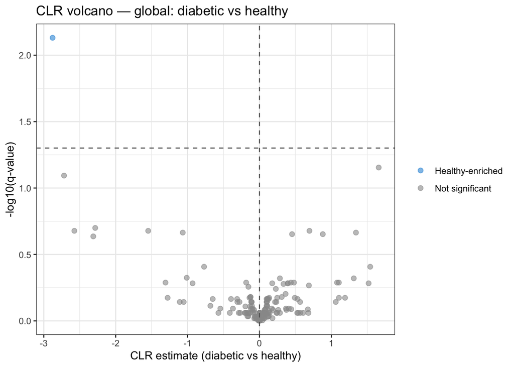

```r
plot_volcano(clr_global,
             x_label   = "CLR estimate (diabetic vs healthy)",
             title     = "CLR volcano — global: diabetic vs healthy",
             pos_label = "Diabetic-enriched",
             neg_label = "Healthy-enriched")
```

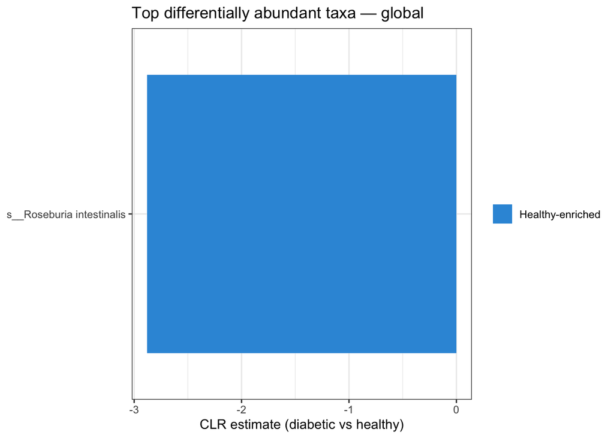

```r
plot_top_taxa(clr_global,
              x_label   = "CLR estimate (diabetic vs healthy)",
              title     = "Top differentially abundant taxa — global",
              pos_label = "Diabetic-enriched",
              neg_label = "Healthy-enriched")
```

## Constrained Ordination — RDA

The CLR matrix is constrained by disease status, country, sex, age, and sequencing depth. This tests which predictors explain significant variation in the full community composition simultaneously.

```r
rda_global_out <- run_rda(
  ps_clr      = global_t$clr,
  formula_str = "Disease.MESH.ID + Country + Sex + as.numeric(Host.age) + as.numeric(Nr..reads.sequenced)",
  covariates  = c("Disease.MESH.ID", "Country", "Sex", "Host.age", "Nr..reads.sequenced")
)
```

```
## Samples removed due to NAs: 19
## Samples retained: 413
```

```r
# Permutation ANOVA — overall model and per-term
anova(rda_global_out$rda, permutations = 999)
```

```
## Permutation test for rda under reduced model
## Permutation: free
## Number of permutations: 999
##
## Model: rda(formula = clr_clean ~ Disease.MESH.ID + Country + Sex + as.numeric(Host.age) + as.numeric(Nr..reads.sequenced), data = meta_clean)
##           Df Variance      F Pr(>F)
## Model      5   116.69 4.5186  0.001 ***
## Residual 407  2102.15
## ---
## Signif. codes:  0 '***' 0.001 '**' 0.01 '*' 0.05 '.' 0.1 ' ' 1
```

```r
anova(rda_global_out$rda, by = "term", permutations = 999)
```

```
## Permutation test for rda under reduced model
## Terms added sequentially (first to last)
## Permutation: free
## Number of permutations: 999
##
## Model: rda(formula = clr_clean ~ Disease.MESH.ID + Country + Sex + as.numeric(Host.age) + as.numeric(Nr..reads.sequenced), data = meta_clean)
##                                  Df Variance       F Pr(>F)
## Disease.MESH.ID                   1    22.70  4.3945  0.001 ***
## Country                           1    74.51 14.4250  0.001 ***
## Sex                               1     7.99  1.5462  0.031 *
## as.numeric(Host.age)              1     6.30  1.2192  0.157
## as.numeric(Nr..reads.sequenced)   1     5.21  1.0082  0.405
## Residual                        407  2102.15
## ---
## Signif. codes:  0 '***' 0.001 '**' 0.01 '*' 0.05 '.' 0.1 ' ' 1
```

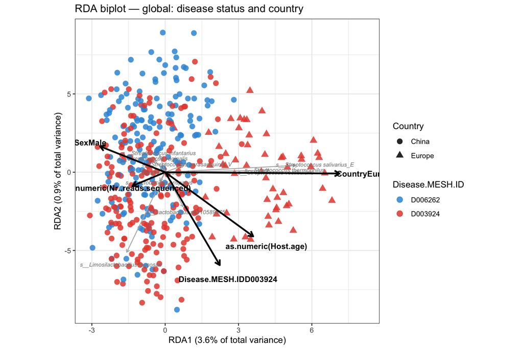

```r
plot_rda_biplot(
  rda_obj      = rda_global_out$rda,
  meta_df      = rda_global_out$meta,
  color_var    = "Disease.MESH.ID",
  shape_var    = "Country",
  color_values = c("D003924" = "#E74C3C", "D006262" = "#3498DB"),
  shape_values = c("China" = 16, "Europe" = 17),
  title        = "RDA biplot — global: disease status and country"
)
```

### RDA vs CLR comparison

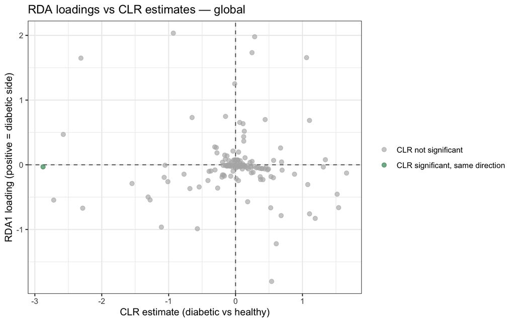

```r
# Sign of RDA1 is arbitrary; orient so that the diabetic group has positive RDA1
rda1_scores_global <- scores(rda_global_out$rda, display = "sites")[, "RDA1"]
rda1_sign_global <- ifelse(
  mean(rda1_scores_global[rda_global_out$meta$Disease.MESH.ID == "D003924"], na.rm = TRUE) >=
  mean(rda1_scores_global[rda_global_out$meta$Disease.MESH.ID == "D006262"], na.rm = TRUE),
  1, -1
)

comp_global <- compare_rda_clr(
  rda_obj  = rda_global_out$rda,
  clr_res  = clr_global,
  tax_df   = as(tax_table(global_t$clr), "matrix") %>% as.data.frame(),
  rda1_sign = rda1_sign_global
)

plot_rda_clr_comparison(
  comp_global,
  x_label = "CLR estimate (diabetic vs healthy)",
  y_label = "RDA1 loading (positive = diabetic side)",
  title   = "RDA loadings vs CLR estimates — global"
)
```

```r
comp_global %>%
  arrange(desc(abs(rda1_loading))) %>%
  select(Phylum.x, Genus.x, rda1_loading, clr_estimate, clr_q, direction_agreement) %>%
  head(20)
```

```
## # A tibble: 20 × 6
##    Phylum.x          Genus.x rda1_loading clr_estimate clr_q direction_agreement
##    <chr>             <chr>          <dbl>        <dbl> <dbl> <lgl>
##  1 p__Bacillota      g__Bla…        2.03       -0.930  0.521 FALSE
##  2 p__Bacillota      g__Ana…        1.98        0.285  0.871 TRUE
##  3 p__Bacteroidota   g__Bac…       -1.80        0.539  0.871 FALSE
##  4 p__Bacillota      g__Dia…        1.73        0.246  0.871 TRUE
##  5 p__Bacillota      g__Rum…        1.66        1.06   0.720 TRUE
##  6 p__Bacillota      g__Aga…        1.65       -2.31   0.231 FALSE
##  7 p__Bacillota      g__Dor…        1.25       -0.0126 0.995 FALSE
##  8 p__Bacteroidota   g__Ali…       -1.22        0.608  0.871 FALSE
##  9 p__Bacteroidota   g__Pho…       -0.988      -0.571  0.871 TRUE
## 10 p__Bacteroidota   g__Pho…       -0.963      -1.11   0.720 TRUE
## 11 p__Bacteroidota   g__Bac…       -0.828       1.19   0.670 FALSE
## 12 p__Pseudomonadota g__Esc…       -0.786       0.681  0.871 FALSE
## 13 p__Bacteroidota   g__Bac…       -0.758       1.11   0.670 FALSE
## 14 p__Bacillota      g__Bla…        0.748      -0.150  0.878 FALSE
## 15 p__Bacillota      g__Cop…        0.730      -0.650  0.684 FALSE
## 16 p__Actinomycetota g__Bif…        0.699       0.442  0.816 TRUE
## 17 p__Verrucomicrob… g__Akk…        0.685       1.10   0.515 TRUE
## 18 p__Bacteroidota   g__Pho…       -0.671      -2.28   0.200 TRUE
## 19 p__Bacteroidota   g__Bac…       -0.665       0.525  0.871 FALSE
## 20 p__Bacillota      g__Rum…       -0.662       1.54   0.391 FALSE
```

# Analysis 2: China — Diabetics vs. Non-Diabetics

**Question:** Within China, is there a difference in the gut microbiome between diabetics and non-diabetics?

## Visualisation

[figure not shown]

```r
ps_species_china  <- tax_glom(china_t$rel, taxrank = "Species")
ps_species_china_sick  <- subset_samples(ps_species_china, Disease.MESH.ID == "D003924")
ps_species_china_healthy  <- subset_samples(ps_species_china, Disease.MESH.ID == "D006262")
ps_species_china_sick_sampled <- sample_ps(ps_species_china_sick, size = min(15, nsamples(ps_species_china_sick)))
ps_species_china_healthy_sampled <- sample_ps(ps_species_china_healthy, size = min(15, nsamples(ps_species_china_healthy)))

china_species_sampled <- merge_phyloseq(ps_species_china_healthy_sampled, ps_species_china_sick_sampled )

plot_bar(china_species_sampled, fill = "Species") +
  facet_nested(~ Disease.MESH.ID, scales = "free_x") +
  labs(title = "Relative abundance by disease status (China)") +
  theme(axis.text.x = element_blank())
```

## Alpha Diversity

```r
alpha_china <- make_alpha_df(ps_china, china_t$pa)
```

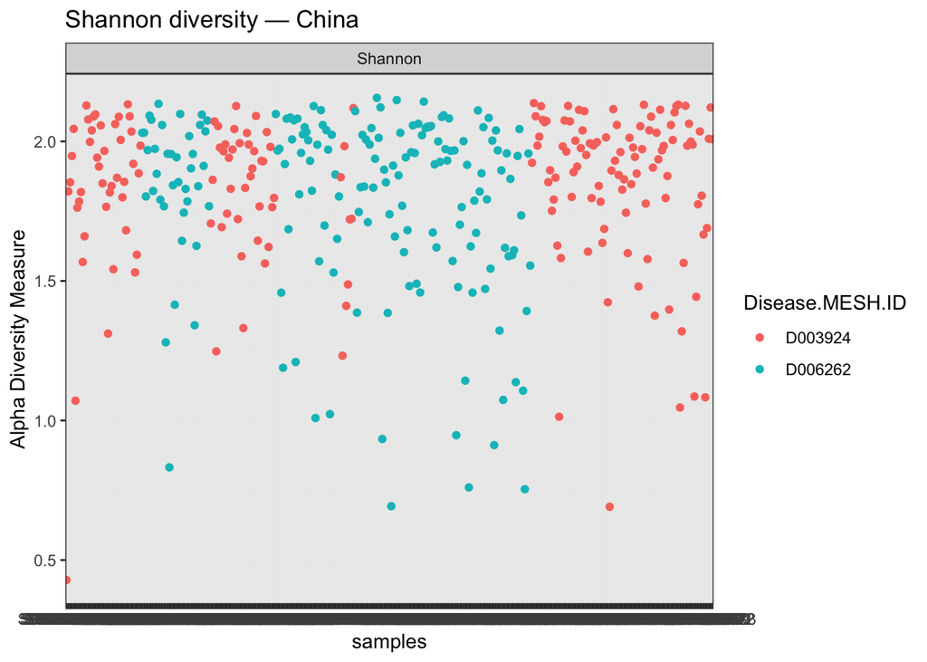

```r
plot_richness(ps_china, measures = "Shannon", color = "Disease.MESH.ID") +
  labs(title = "Shannon diversity — China") +
  theme_bw()
```

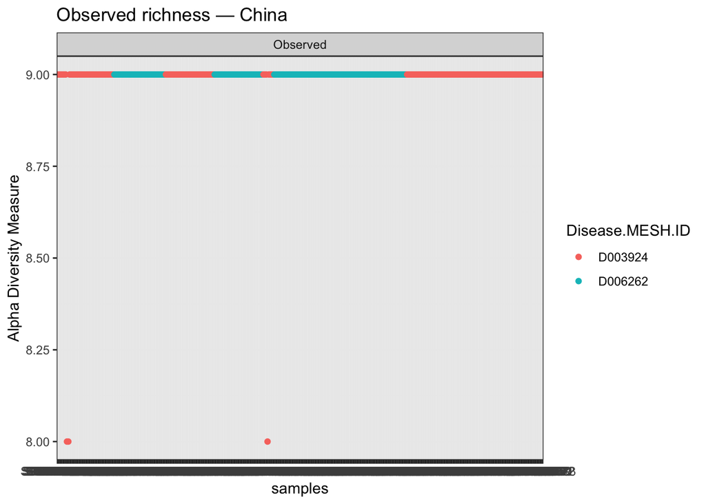

```r
plot_richness(china_t$pa, measures = "Observed", color = "Disease.MESH.ID") +
  labs(title = "Observed richness — China") +
  theme_bw()
```

```r
run_kruskal(alpha_china, "Shannon", "Disease.MESH.ID")
```

```
##                                   Variable Chi_squared df   P_value
## Kruskal-Wallis chi-squared Disease.MESH.ID    1.465117  1 0.2261177
```

```r
run_pairwise_wilcoxon(alpha_china, "Shannon", "Disease.MESH.ID")
```

```
## # A tibble: 1 × 5
##   Variable        Comparison         P_value_adj Group1  Group2
##   <chr>           <chr>                    <dbl> <chr>   <chr>
## 1 Disease.MESH.ID D006262 vs D003924       0.226 D006262 D003924
```

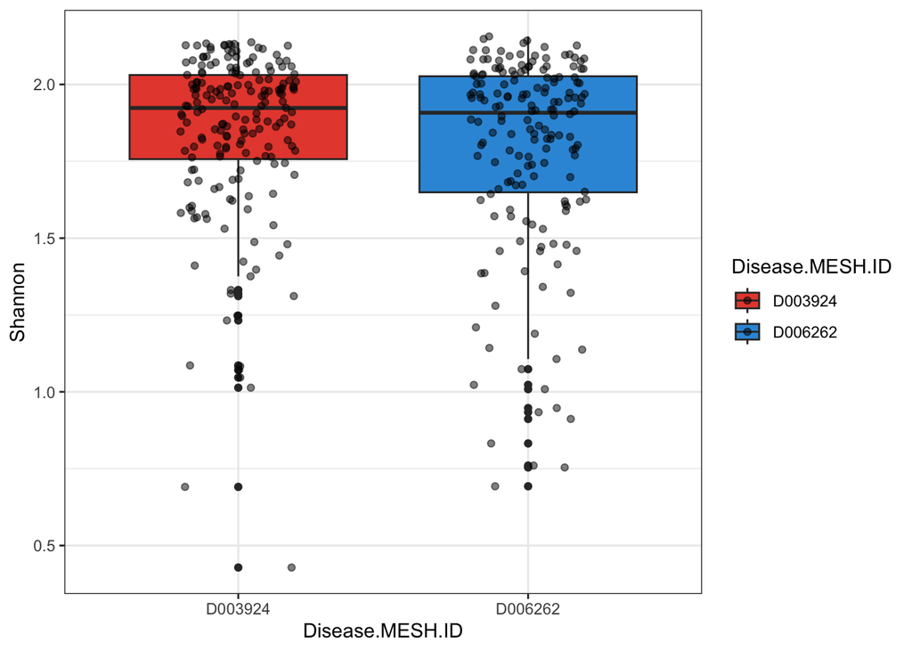

```r
ggplot(alpha_china, aes(x = Disease.MESH.ID, y = Shannon, fill = Disease.MESH.ID)) +
  geom_boxplot() +
  geom_jitter(width = 0.2, alpha = 0.5) +
  theme_bw() +
  scale_fill_manual(values = c("#E74C3C", "#3498DB"))
```

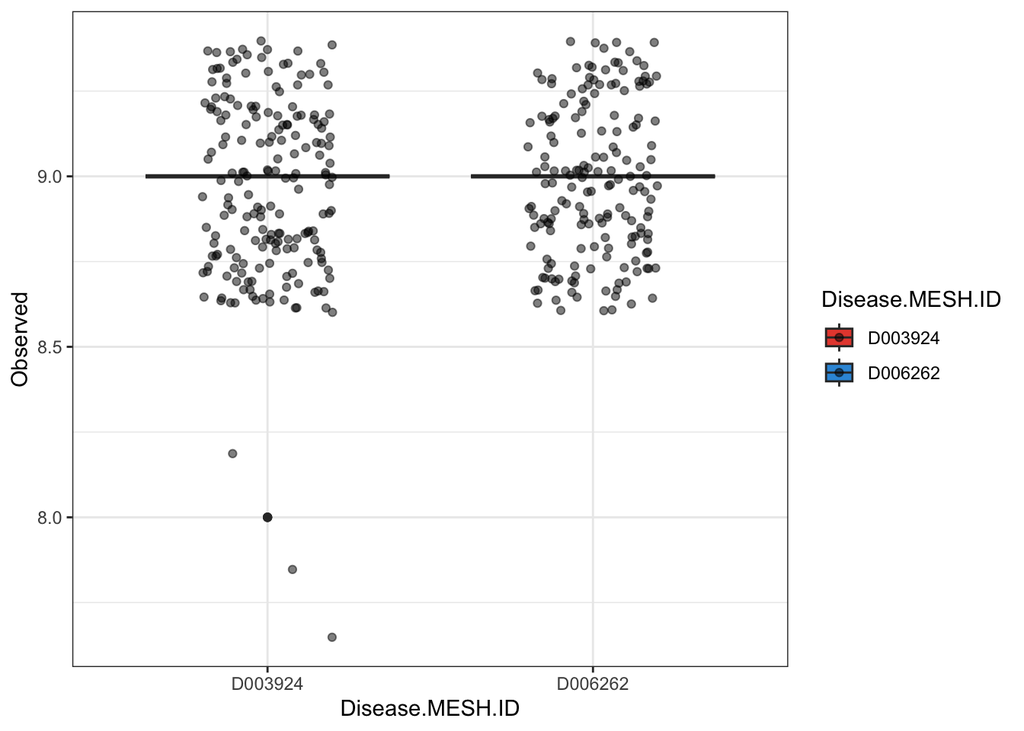

```r
ggplot(alpha_china, aes(x = Disease.MESH.ID, y = Observed, fill = Disease.MESH.ID)) +
  geom_boxplot() +
  geom_jitter(width = 0.2, alpha = 0.5) +
  theme_bw() +
  scale_fill_manual(values = c("#E74C3C", "#3498DB"))
```

### Sequencing depth vs. Shannon

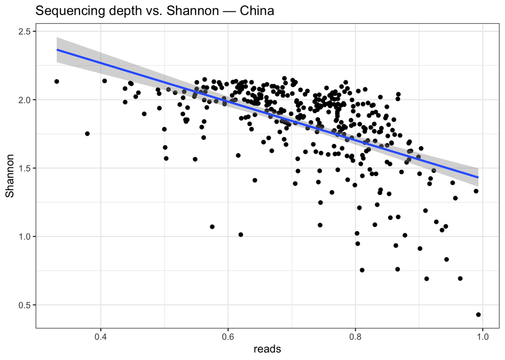

```r
alpha_china$reads <- sample_sums(ps_china)[alpha_china$sample_id]

ggplot(alpha_china, aes(x = reads, y = Shannon)) +
  geom_point() + geom_smooth(method = "lm") +
  labs(title = "Sequencing depth vs. Shannon — China") +
  theme_bw()
```

```r
cor.test(alpha_china$reads, alpha_china$Shannon, method = "spearman")
```

```
##
##  Spearman's rank correlation rho
##
## data:  alpha_china$reads and alpha_china$Shannon
## S = 12220212, p-value < 2.2e-16
## alternative hypothesis: true rho is not equal to 0
## sample estimates:
##        rho
## -0.5847108
```

## Beta Diversity — PERMANOVA

### Calculating the Bray-Curtis distances and the Jaccard distances

```r
bray_dist <- distance(
  ps_china,
  method = "bray"
)

jaccard_dist <- distance(
  china_t$pa,
  method = "jaccard"
)
```

### NMDS based on Bray-Curtis distance

NMDS is another commonly used ordination method in ecology and microbiome analysis. Unlike PCoA, it focuses on preserving the rank order of distances rather than the distances themselves.

```r
global_nmds <- ordinate(
  china_t$rel,
  method = "NMDS",
  distance = "bray"
)
```

```
## *** Best solution was not repeated -- monoMDS stopping criteria:
##      5: no. of iterations >= maxit
##     14: stress ratio > sratmax
##      1: scale factor of the gradient < sfgrmin
```

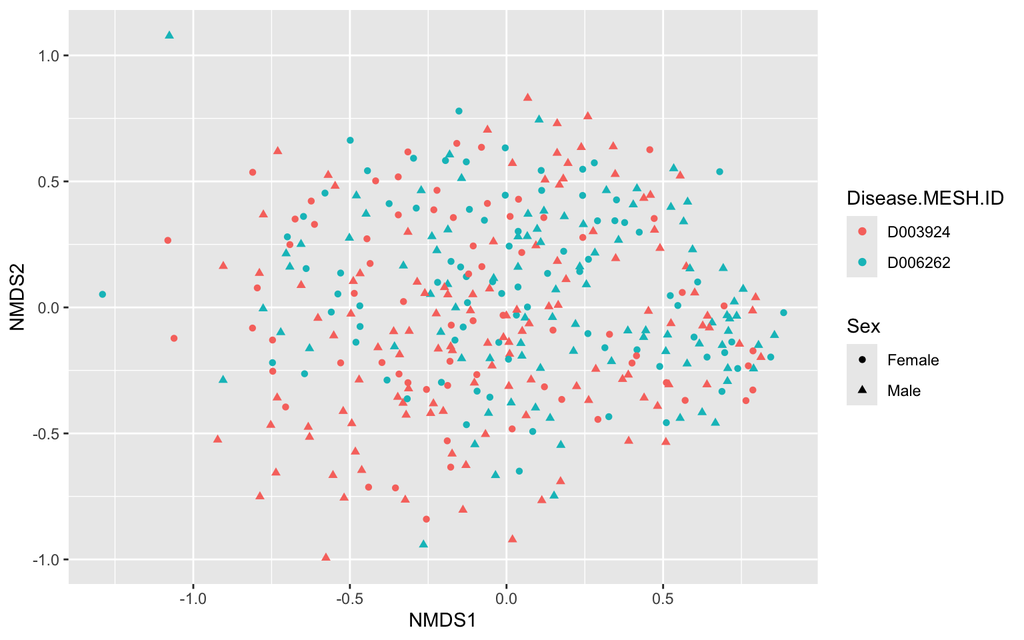

```r
plot_ordination(
  china_t$rel,
  global_nmds,
  type = "samples",
  color = "Disease.MESH.ID",
  shape = "Sex"
)
```

### PERMANOVA + Dispersion

```r
bray_china <- distance(china_t$rel, method = "bray")
ord_china  <- ordinate(china_t$rel, method = "PCoA", distance = bray_china)

sample_df_china <- sample_data(china_t$rel) %>% data.frame()

adonis2(bray_china ~ Disease.MESH.ID,
        data = sample_df_china, permutations = 999)
```

```
## Permutation test for adonis under reduced model
## Permutation: free
## Number of permutations: 999
##
## adonis2(formula = bray_china ~ Disease.MESH.ID, data = sample_df_china, permutations = 999)
##           Df SumOfSqs      R2      F Pr(>F)
## Model      1    1.496 0.01144 4.1331  0.001 ***
## Residual 357  129.236 0.98856
## Total    358  130.732 1.00000
## ---
## Signif. codes:  0 '***' 0.001 '**' 0.01 '*' 0.05 '.' 0.1 ' ' 1
```

```r
adonis2(bray_china ~ Nr..reads.sequenced,
        data = sample_df_china, permutations = 999)
```

```
## Permutation test for adonis under reduced model
## Permutation: free
## Number of permutations: 999
##
## adonis2(formula = bray_china ~ Nr..reads.sequenced, data = sample_df_china, permutations = 999)
##           Df SumOfSqs      R2      F Pr(>F)
## Model      1    0.442 0.00338 1.2099  0.254
## Residual 357  130.290 0.99662
## Total    358  130.732 1.00000
```

```r
disp_china <- betadisper(bray_china, sample_df_china$Disease.MESH.ID)
anova(disp_china)
```

```
## Analysis of Variance Table
##
## Response: Distances
##            Df  Sum Sq   Mean Sq F value   Pr(>F)
## Groups      1 0.03059 0.0305943  7.8982 0.005221 **
## Residuals 357 1.38286 0.0038736
## ---
## Signif. codes:  0 '***' 0.001 '**' 0.01 '*' 0.05 '.' 0.1 ' ' 1
```

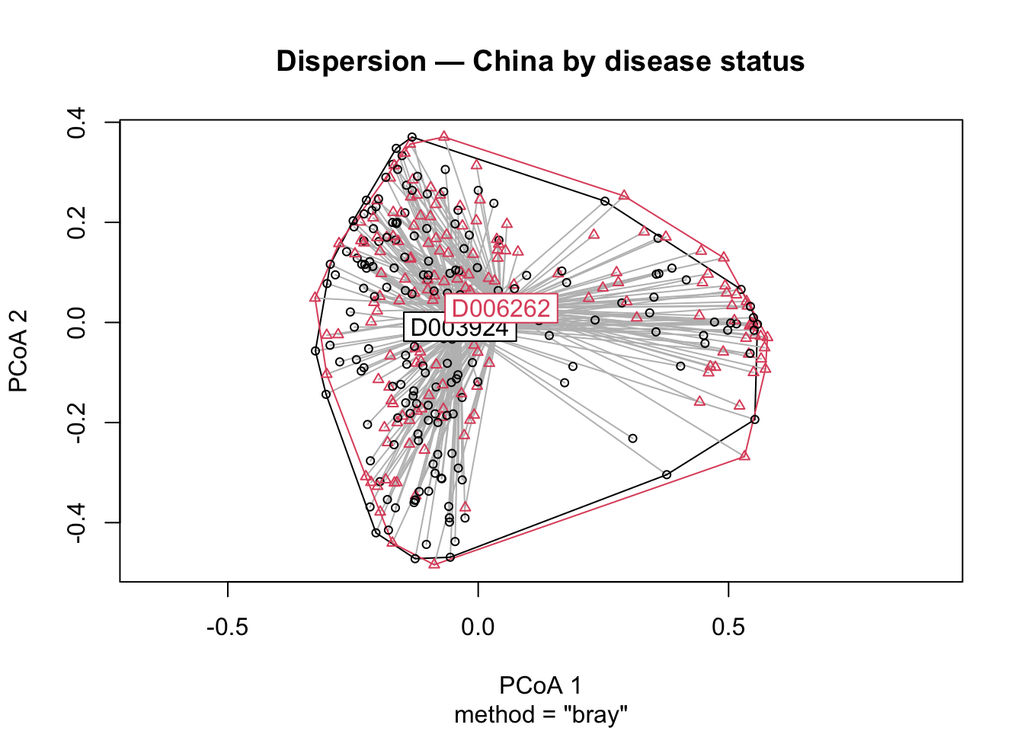

```r
plot(disp_china, main = "Dispersion — China by disease status")
```

### PCoA — Bray-Curtis

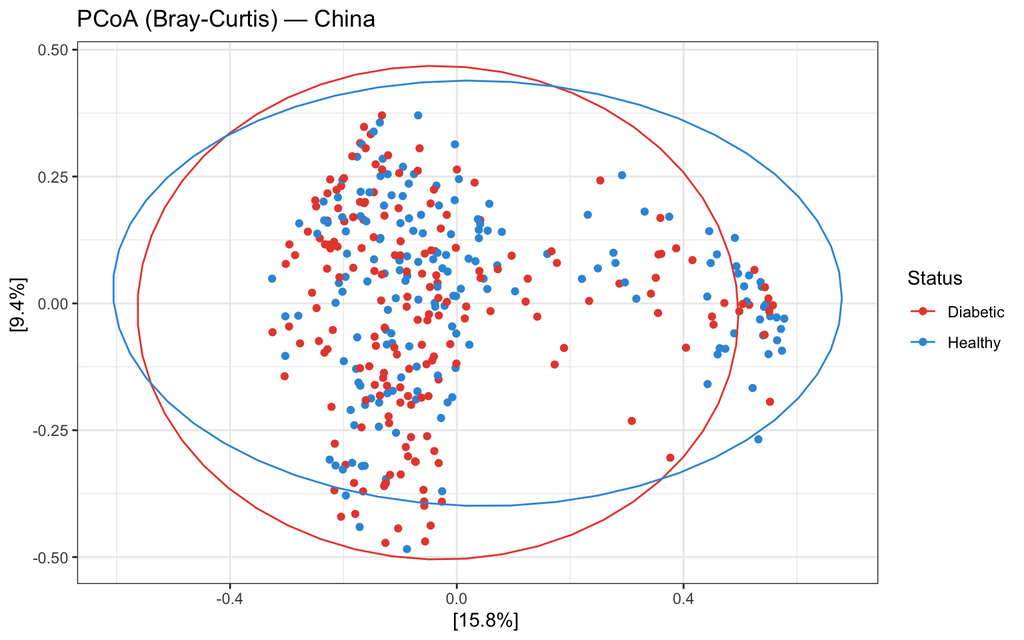

```r
plot_ordination(china_t$rel, ord_china, type = "samples",
                color = "Disease.MESH.ID") +
  stat_ellipse(aes(color = Disease.MESH.ID),
               type = "norm",    # or "t" for robust ellipses
               level = 0.95) +   # 95% confidence ellipse
  scale_color_manual(values = c("D003924" = "#E74C3C", "D006262" = "#3498DB"),
                     labels = c("Diabetic", "Healthy")) +
  labs(title = "PCoA (Bray-Curtis) — China",
       color = "Status") +
  theme_bw()
```

### Jaccard

```r
jaccard_china <- distance(china_t$rel, method = "jaccard")
ord_j_china  <- ordinate(china_t$rel, method = "PCoA", distance = jaccard_china)

sample_df2_china <- sample_data(china_t$pa) %>% data.frame()

adonis2(jaccard_china ~ Disease.MESH.ID,
        data = sample_df2_china, permutations = 999)
```

```
## Permutation test for adonis under reduced model
## Permutation: free
## Number of permutations: 999
##
## adonis2(formula = jaccard_china ~ Disease.MESH.ID, data = sample_df2_china, permutations = 999)
##           Df SumOfSqs      R2      F Pr(>F)
## Model      1    1.265 0.00848 3.0522  0.001 ***
## Residual 357  147.976 0.99152
## Total    358  149.241 1.00000
## ---
## Signif. codes:  0 '***' 0.001 '**' 0.01 '*' 0.05 '.' 0.1 ' ' 1
```

```r
dispj_china <- betadisper(jaccard_china, sample_df_china$Disease.MESH.ID)
anova(dispj_china)
```

```
## Analysis of Variance Table
##
## Response: Distances
##            Df  Sum Sq   Mean Sq F value   Pr(>F)
## Groups      1 0.01529 0.0152874  9.6418 0.002054 **
## Residuals 357 0.56603 0.0015855
## ---
## Signif. codes:  0 '***' 0.001 '**' 0.01 '*' 0.05 '.' 0.1 ' ' 1
```

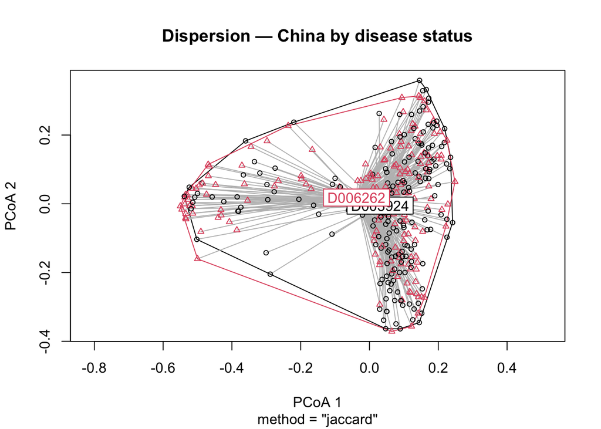

```r
plot(dispj_china, main = "Dispersion — China by disease status")
```

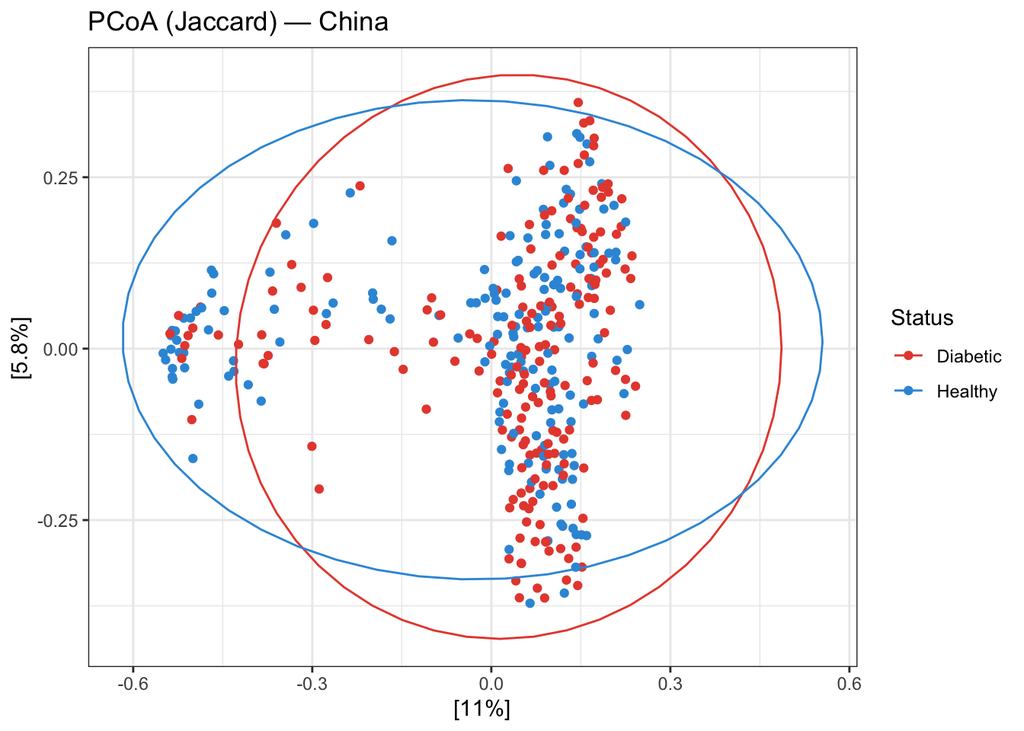

```r
plot_ordination(china_t$rel, ord_j_china, type = "samples",
                color = "Disease.MESH.ID") +
  stat_ellipse(aes(color = Disease.MESH.ID),
               type = "norm",    # or "t" for robust ellipses
               level = 0.95) +   # 95% confidence ellipse
  scale_color_manual(values = c("D003924" = "#E74C3C", "D006262" = "#3498DB"),
                     labels = c("Diabetic", "Healthy")) +
  labs(title = "PCoA (Jaccard) — China",
       color = "Status") +
  theme_bw()
```